# Data 607 - Project 2

Peter Kowalchuk

September 26, 2018

# Project 2

```r
library(stringr)
library(rvest)
library(dplyr)
```

```r
library(tidyr)
library(kableExtra)
library(ggplot2)
library("RMySQL")
```

## Dataset 1

### Wiki - List of Grand Slam men’s singles champions by Peter Kowalchuk

https://en.wikipedia.org/wiki/List_of_Grand_Slam_men%27s_singles_champions

The wiki page for the List of Grand Slam men’s singles champions shows a table with a list of all the winners of Grand Slam tournaments. It can be found at this url: https://en.wikipedia.org/wiki/List_of_Grand_Slam_men%27s_singles_champions

The table has 5 columns. The first is the year, and the following 4 are one for each Grand Slam tournament. Each row on the table constitutes an entry for the results, winner, for each of the four grand slam tournaments. If we revisit the guideline of what a tidy table is, we can quickly see that this table does not comply with such approach. In tidy, we should have columns for each variable, and the rows should represent observation entries. That is clearly not the case, as the column represent an actual characteristic of the observation. Observations being in this case the results of each tournament. On the table shown in wiki, there are columns for the tournament names, which breaks the tidy framework.

To have a tidy compliant table, we should have columns for variables. This can be achieved by setting our columns to: year, tournament name, player name. With these simple three columns, we can not enter on each row the results for each tournament. In fact, we could break out some of the information on the original table cells to add more columns with variables. For example, we could add another column with the player’s country, and another with the tournaments location. With this structure, we would add a row to the table each time a tournament is completed and the winner is known. We could even add other tournaments beyond Grand Slams like ATP Master tournaments. Another column that might be added is an identifier for the kind of tournament, tournament type for example. This might show GS for the original tournaments in wiki, and maybe ATPM for ATP Masters, EX for exhibition games, and so on.

But even with the original data in wiki, we can now do a lot more with the table in this new tidy form. We can for instance group rows in the table per country of winning player and calculate which country has won more tournaments. We can do the same with player names. We can also filter by tournament and run the same grouping and quickly know who has won specific tournaments the most. Knowing Wimbledon is played on grass and the French Open in clay, we can also know which country has the best clay or grass players, or which player specifically is better at a given surface.

By arranging the table into a tidy format, we are now able to extract a great amount of information from the same data presented in the original table. And on top of that we are able to expand the table to new tournaments or observations, and add characteristics or variables of these tournaments very easily. Not only is the table easier to use with existing data, we can now expand the tale beyond the data original contained in it.

```r
url<-'https://en.wikipedia.org/wiki/List_of_Grand_Slam_men%27s_singles_champions'
webPage<- url %>% read_html()
#Using the selectorgadget in chrome we find the CSS selector to bring in the table as a vector
#The table in the html page is anot a clean table with cells so scrapping it with a table tag is not the right approach
vectorTable<-webPage %>% html_nodes('tr td') %>% html_text()
#build vector with string elements for each year
years<-paste(c(1877:2018))
#we trim vectorTable to be the size of the table if the table had names for all its rows
vectorTable<-vectorTable[1:(length(years)*5)]
#we find that the resulting vector includes elements which go bejond the table
#we trim the vector down to just the elements on the table
#find element position for each year in vectorTable, this tells us where the rows are
m<-match(years,vectorTable)
#find number of elements between years, if all 4 tournament data is present, then differene should be 5
#this tells us where the rows with complete data are
n<-diff(m)
#we copy all the years with complete tournament data on to a new vector
x<-c()
i<-1
for (nn in n) {if (n[i]==5) {x<-c(x,vectorTable[m[i]:(m[i]+4)])}; i<-i+1}
x<-c(x,vectorTable[m[i]:(m[i]+4)])
#we copy the resulting vector with al the table rows with data on to a data frame using the new tidy table format -this is still a wide table
tblTable<-tbl_df(as.data.frame(matrix(x,nrow=length(x)/5,ncol=5,byrow = TRUE)))
#we assign proper column names to the data frame
tblTable<-setNames(tblTable,c('Year','Australian Open','French Open','Wimbledon','US Open'))
tblTable %>% kable() %>% kable_styling() %>% scroll_box(width = "910px", height = "400px")
```

| Year | Australian Open | French Open | Wimbledon | US Open |
| --- | --- | --- | --- | --- |
| 1877 | started in 1905 | started in 1891 | GBR: Spencer Gore | started in 1881 |
| 1878 | tournament not created | tournament not created | Frank Hadow | tournament not created |
| 1879 | tournament not created | tournament not created | John Hartley (1/2) | tournament not created |
| 1880 | tournament not created | tournament not created | John Hartley (2/2) | tournament not created |
| 1881 | tournament not created | tournament not created | William Renshaw (1/7) | USA: Richard Sears (1/7) |
| 1882 | tournament not created | tournament not created | William Renshaw (2/7) | Richard Sears (2/7) |
| 1883 | tournament not created | tournament not created | William Renshaw (3/7) | Richard Sears (3/7) |
| 1884 | tournament not created | tournament not created | William Renshaw (4/7) | Richard Sears (4/7) |
| 1885 | tournament not created | tournament not created | William Renshaw (5/7) | Richard Sears (5/7) |
| 1886 | tournament not created | tournament not created | William Renshaw (6/7) | Richard Sears (6/7) |
| 1887 | tournament not created | tournament not created | Herbert Lawford | Richard Sears (7/7) |
| 1888 | tournament not created | tournament not created | Ernest Renshaw | Henry Slocum (1/2) |
| 1889 | tournament not created | tournament not created | William Renshaw (7/7) | Henry Slocum (2/2) |
| 1890 | tournament not created | tournament not created | Willoughby Hamilton | Oliver Campbell (1/3) |
| 1891 | tournament not created | H. Briggs * | Wilfred Baddeley (1/3) | Oliver Campbell (2/3) |
| 1892 | tournament not created | FRA: Jean Schopfer * | Wilfred Baddeley (2/3) | Oliver Campbell (3/3) |
| 1893 | tournament not created | Laurent Riboulet * | Joshua Pim (1/2) | Robert Wrenn (1/4) |
| 1894 | tournament not created | André Vacherot * | Joshua Pim (2/2) | Robert Wrenn (2/4) |
| 1895 | tournament not created | André Vacherot * | Wilfred Baddeley (3/3) | Fred Hovey |
| 1896 | tournament not created | André Vacherot * | Harold Mahony | Robert Wrenn (3/4) |
| 1897 | tournament not created | Paul Aymé * | Reginald Doherty (1/4) | Robert Wrenn (4/4) |
| 1898 | tournament not created | Paul Aymé * | Reginald Doherty (2/4) | Malcolm Whitman (1/3) |
| 1899 | tournament not created | Paul Aymé * | Reginald Doherty (3/4) | Malcolm Whitman (2/3) |
| 1900 | tournament not created | Paul Aymé * | Reginald Doherty (4/4) | Malcolm Whitman (3/3) |
| 1901 | tournament not created | André Vacherot * | Arthur Gore (1/3) | William Larned (1/7) |
| 1902 | tournament not created | Michel Vacherot * | Laurence Doherty (1/6) | William Larned (2/7) |
| 1903 | tournament not created | Max Decugis * | Laurence Doherty (2/6) | Laurence Doherty (3/6) |
| 1904 | tournament not created | Max Decugis * | Laurence Doherty (4/6) | Holcombe Ward |
| 1905 | AUS: Rodney Heath (1/2) | Maurice Germot * | Laurence Doherty (5/6) | Beals Wright |
| 1906 | NZL: Anthony Wilding (1/6) | Maurice Germot * | Laurence Doherty (6/6) | William Clothier |

[output cut: 102 more lines]

```r
#we save the table to a csv file
write.csv(tblTable,file="grandSlamWinners.csv",row.names=FALSE)
#we can read this csv file
tblTable<-tbl_df(read.csv(file="grandSlamWinners.csv", header=TRUE, sep=",",colClasses = "character"))
tblTable<-setNames(tblTable,c('Year','Australian Open','French Open','Wimbledon','US Open'))

#we can also connect to a mySQL server and write the table there
#in mySQL we create a schema for our table and then we can write and read the table
mydb<-dbConnect(MySQL(),user='root',password='1234',dbname='tennis',host='localhost')
dbWriteTable(mydb, value = tblTable, name = "grandSlam")
```

```
## [1] TRUE
```

```r
sqlTable<-dbReadTable(mydb,"grandSlam")
sqlTable %>% kable() %>% kable_styling() %>% scroll_box(width = "910px", height = "400px")
```

| Year | Australian.Open | French.Open | Wimbledon | US.Open |
| --- | --- | --- | --- | --- |
| 1877 | started in 1905 | started in 1891 | GBR: Spencer Gore | started in 1881 |
| 1878 | tournament not created | tournament not created | Frank Hadow | tournament not created |
| 1879 | tournament not created | tournament not created | John Hartley (1/2) | tournament not created |
| 1880 | tournament not created | tournament not created | John Hartley (2/2) | tournament not created |
| 1881 | tournament not created | tournament not created | William Renshaw (1/7) | USA: Richard Sears (1/7) |
| 1882 | tournament not created | tournament not created | William Renshaw (2/7) | Richard Sears (2/7) |
| 1883 | tournament not created | tournament not created | William Renshaw (3/7) | Richard Sears (3/7) |
| 1884 | tournament not created | tournament not created | William Renshaw (4/7) | Richard Sears (4/7) |
| 1885 | tournament not created | tournament not created | William Renshaw (5/7) | Richard Sears (5/7) |
| 1886 | tournament not created | tournament not created | William Renshaw (6/7) | Richard Sears (6/7) |
| 1887 | tournament not created | tournament not created | Herbert Lawford | Richard Sears (7/7) |
| 1888 | tournament not created | tournament not created | Ernest Renshaw | Henry Slocum (1/2) |
| 1889 | tournament not created | tournament not created | William Renshaw (7/7) | Henry Slocum (2/2) |
| 1890 | tournament not created | tournament not created | Willoughby Hamilton | Oliver Campbell (1/3) |
| 1891 | tournament not created | H. Briggs * | Wilfred Baddeley (1/3) | Oliver Campbell (2/3) |
| 1892 | tournament not created | FRA: Jean Schopfer * | Wilfred Baddeley (2/3) | Oliver Campbell (3/3) |
| 1893 | tournament not created | Laurent Riboulet * | Joshua Pim (1/2) | Robert Wrenn (1/4) |
| 1894 | tournament not created | André Vacherot * | Joshua Pim (2/2) | Robert Wrenn (2/4) |
| 1895 | tournament not created | André Vacherot * | Wilfred Baddeley (3/3) | Fred Hovey |
| 1896 | tournament not created | André Vacherot * | Harold Mahony | Robert Wrenn (3/4) |
| 1897 | tournament not created | Paul Aymé * | Reginald Doherty (1/4) | Robert Wrenn (4/4) |
| 1898 | tournament not created | Paul Aymé * | Reginald Doherty (2/4) | Malcolm Whitman (1/3) |
| 1899 | tournament not created | Paul Aymé * | Reginald Doherty (3/4) | Malcolm Whitman (2/3) |
| 1900 | tournament not created | Paul Aymé * | Reginald Doherty (4/4) | Malcolm Whitman (3/3) |
| 1901 | tournament not created | André Vacherot * | Arthur Gore (1/3) | William Larned (1/7) |
| 1902 | tournament not created | Michel Vacherot * | Laurence Doherty (1/6) | William Larned (2/7) |
| 1903 | tournament not created | Max Decugis * | Laurence Doherty (2/6) | Laurence Doherty (3/6) |
| 1904 | tournament not created | Max Decugis * | Laurence Doherty (4/6) | Holcombe Ward |
| 1905 | AUS: Rodney Heath (1/2) | Maurice Germot * | Laurence Doherty (5/6) | Beals Wright |
| 1906 | NZL: Anthony Wilding (1/6) | Maurice Germot * | Laurence Doherty (6/6) | William Clothier |

[output cut: 102 more lines]

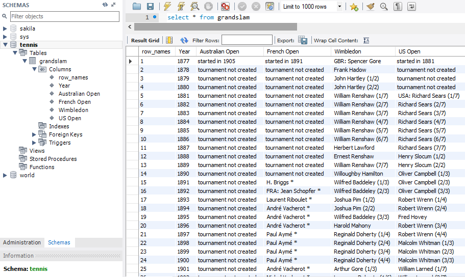

```r
#Now that we have a a wide table we build our tidy table using gather
tidyTable<-gather(tblTable,"Tournament","Player",2:5)
#we do some heavy lifting to clean each cell
tidyTable$Player<-str_extract(tidyTable$Player,"[A-Z][:alpha:]+ [A-Z]'[A-Z][:alpha:]+ [:alpha:]+|[A-Z][:alpha:]+ [A-Z][:alpha:]+|[A-Z]\\. [:alpha:]+")
tidyTable$Player[tidyTable$Player=="World War"]<-NA
tidyTable$Player[tidyTable$Player=="Tournament date"]<-NA
tidyTable<-tidyTable %>% na.omit()
tidyTable %>% kable() %>% kable_styling() %>% scroll_box(width = "910px", height = "400px")
```

| Year | Tournament | Player |
| --- | --- | --- |
| 1905 | Australian Open | Rodney Heath |
| 1906 | Australian Open | Anthony Wilding |
| 1907 | Australian Open | Horace Rice |
| 1908 | Australian Open | Fred Alexander |
| 1909 | Australian Open | Anthony Wilding |
| 1910 | Australian Open | Rodney Heath |
| 1911 | Australian Open | Norman Brookes |
| 1912 | Australian Open | James Cecil |
| 1913 | Australian Open | Ernie Parker |
| 1914 | Australian Open | Arthur O’Hara Wood |
| 1915 | Australian Open | Francis Lowe |
| 1920 | Australian Open | Pat O’Hara Wood |
| 1921 | Australian Open | Rhys Gemmell |
| 1922 | Australian Open | James Anderson |
| 1923 | Australian Open | Pat O’Hara Wood |
| 1924 | Australian Open | James Anderson |
| 1925 | Australian Open | James Anderson |
| 1926 | Australian Open | John Hawkes |
| 1927 | Australian Open | Gerald Patterson |
| 1928 | Australian Open | Jean Borotra |
| 1929 | Australian Open | John Gregory |
| 1930 | Australian Open | Edgar Moon |
| 1931 | Australian Open | Jack Crawford |
| 1932 | Australian Open | Jack Crawford |
| 1933 | Australian Open | Jack Crawford |
| 1934 | Australian Open | Fred Perry |
| 1935 | Australian Open | Jack Crawford |
| 1936 | Australian Open | Adrian Quist |
| 1937 | Australian Open | Vivian McGrath |
| 1938 | Australian Open | Don Budge |

[output cut: 445 more lines]

### Players with most wins

```r
tidyTable %>% group_by(Player) %>% summarise(Total_Wins=n())  %>% arrange(desc(Total_Wins)) %>% kable() %>% kable_styling() %>% scroll_box(width = "910px", height = "400px")
```

| Player | Total_Wins |
| --- | --- |
| Roger Federer | 20 |
| Rafael Nadal | 17 |
| Novak Djokovic | 14 |
| Pete Sampras | 14 |
| Roy Emerson | 12 |
| Rod Laver | 11 |
| Bill Tilden | 10 |
| Björn Borg | 10 |
| Andre Agassi | 8 |
| Fred Perry | 8 |
| Henri Cochet | 8 |
| Ivan Lendl | 8 |
| Jimmy Connors | 8 |
| Ken Rosewall | 8 |
| Max Decugis | 8 |
| John McEnroe | 7 |
| John Newcombe | 7 |
| Mats Wilander | 7 |
| René Lacoste | 7 |
| Richard Sears | 7 |
| William Larned | 7 |
| William Renshaw | 7 |
| Anthony Wilding | 6 |
| Boris Becker | 6 |
| Don Budge | 6 |
| Jack Crawford | 6 |
| Laurence Doherty | 6 |
| Stefan Edberg | 6 |
| Frank Sedgman | 5 |
| Jean Borotra | 5 |

[output cut: 124 more lines]

```r
tidyOrder<-tidyTable %>% group_by(Player) %>% summarise(Total_Wins=n()) %>% top_n(50)
```

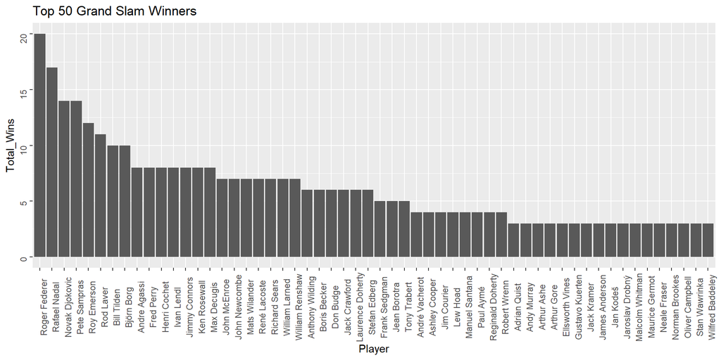

```r
tidyOrder$Player<-factor(tidyOrder$Player,levels = tidyOrder$Player[order(-tidyOrder$Total_Wins)])
ggplot(data=tidyOrder,aes(x=Player, y=Total_Wins))+geom_bar(stat = "identity")+theme(axis.text = element_text(angle=90))+ggtitle("Top 50 Grand Slam Winners")
```

### Australian Open players with most wins

```r
tidyOrder<-tidyTable %>% filter(Tournament=="Australian Open") %>% group_by(Player) %>% summarise(Total_Wins=n())
tidyOrder %>% arrange(desc(Total_Wins)) %>% kable() %>% kable_styling() %>% scroll_box(width = "910px", height = "400px")
```

| Player | Total_Wins |
| --- | --- |
| Novak Djokovic | 6 |
| Roger Federer | 6 |
| Roy Emerson | 6 |
| Andre Agassi | 4 |
| Jack Crawford | 4 |
| Ken Rosewall | 4 |
| Adrian Quist | 3 |
| James Anderson | 3 |
| Mats Wilander | 3 |
| Rod Laver | 3 |
| Anthony Wilding | 2 |
| Ashley Cooper | 2 |
| Boris Becker | 2 |
| Frank Sedgman | 2 |
| Guillermo Vilas | 2 |
| Ivan Lendl | 2 |
| Jim Courier | 2 |
| Johan Kriek | 2 |
| John Bromwich | 2 |
| John Newcombe | 2 |
| Pat O’Hara Wood | 2 |
| Pete Sampras | 2 |
| Rodney Heath | 2 |
| Stefan Edberg | 2 |
| Alex Olmedo | 1 |
| Arthur Ashe | 1 |
| Arthur O’Hara Wood | 1 |
| Brian Teacher | 1 |
| Dinny Pails | 1 |
| Don Budge | 1 |
| Edgar Moon | 1 |
| Ernie Parker | 1 |
| Francis Lowe | 1 |
| Fred Alexander | 1 |
| Fred Perry | 1 |
| Gerald Patterson | 1 |
| Horace Rice | 1 |
| James Cecil | 1 |
| Jean Borotra | 1 |
| Jimmy Connors | 1 |
| John Gregory | 1 |
| John Hawkes | 1 |
| Ken McGregor | 1 |
| Lew Hoad | 1 |
| Marat Safin | 1 |
| Mark Edmondson | 1 |
| Mervyn Rose | 1 |
| Norman Brookes | 1 |
| Petr Korda | 1 |
| Rafael Nadal | 1 |
| Rhys Gemmell | 1 |
| Richard Savitt | 1 |
| Stan Wawrinka | 1 |
| Thomas Johansson | 1 |
| Vivian McGrath | 1 |
| William Bowrey | 1 |
| Yevgeny Kafelnikov | 1 |

```r
tidyOrder<-tidyOrder %>% top_n(50)
```

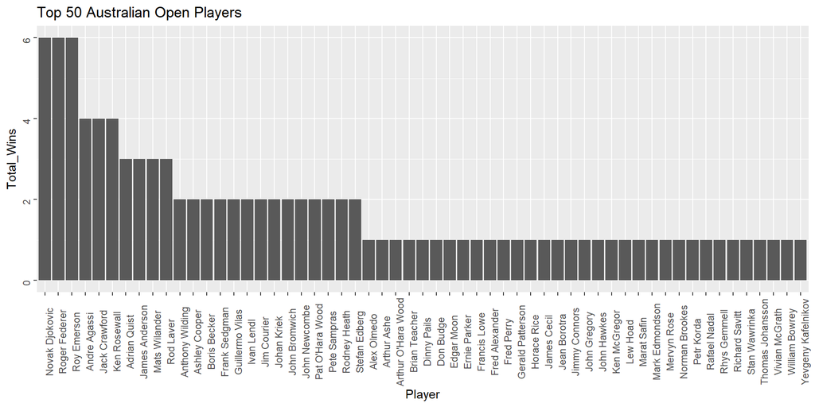

```r
tidyOrder$Player<-factor(tidyOrder$Player,levels = tidyOrder$Player[order(-tidyOrder$Total_Wins)])
ggplot(data=tidyOrder,aes(x=Player, y=Total_Wins))+geom_bar(stat = "identity")+theme(axis.text = element_text(angle=90))+ggtitle("Top 50 Australian Open Players")
```

### French Open players with most wins

```r
tidyOrder<-tidyTable %>% filter(Tournament=="French Open") %>% group_by(Player) %>% summarise(Total_Wins=n())
tidyOrder %>% arrange(desc(Total_Wins)) %>% kable() %>% kable_styling() %>% scroll_box(width = "910px", height = "400px")
```

| Player | Total_Wins |
| --- | --- |
| Rafael Nadal | 11 |
| Max Decugis | 8 |
| Björn Borg | 6 |
| Henri Cochet | 5 |
| André Vacherot | 4 |
| Paul Aymé | 4 |
| Gustavo Kuerten | 3 |
| Ivan Lendl | 3 |
| Mats Wilander | 3 |
| Maurice Germot | 3 |
| René Lacoste | 3 |
| André Gobert | 2 |
| Frank Parker | 2 |
| Jan Kode | 2 |
| Jaroslav Drobný | 2 |
| Jean Borotra | 2 |
| Jim Courier | 2 |
| Ken Rosewall | 2 |
| Manuel Santana | 2 |
| Nicola Pietrangeli | 2 |
| Rod Laver | 2 |
| Roy Emerson | 2 |
| Sergi Bruguera | 2 |
| Tony Trabert | 2 |
| Adriano Panatta | 1 |
| Albert Costa | 1 |
| Andre Agassi | 1 |
| Andrés Gimeno | 1 |
| Andrés Gómez | 1 |
| Budge Patty | 1 |
| Carlos Moyá | 1 |
| Don Budge | 1 |
| Don McNeill | 1 |
| François Blanchy | 1 |
| Fred Perry | 1 |
| Fred Stolle | 1 |
| Gastón Gaudio | 1 |
| H. Briggs | 1 |
| Henner Henkel | 1 |
| Ilie Nastase | 1 |
| Jack Crawford | 1 |
| Jean Samazeuilh | 1 |
| Jean Schopfer | 1 |
| József Asbóth | 1 |
| Juan Carlos | 1 |
| Laurent Riboulet | 1 |
| Lew Hoad | 1 |
| Marcel Bernard | 1 |
| Mervyn Rose | 1 |
| Michael Chang | 1 |
| Michel Vacherot | 1 |
| Novak Djokovic | 1 |
| Roger Federer | 1 |
| Stan Wawrinka | 1 |
| Sven Davidson | 1 |
| Thomas Muster | 1 |
| Tony Roche | 1 |
| Yannick Noah | 1 |
| Yevgeny Kafelnikov | 1 |

```r
tidyOrder<-tidyOrder %>% top_n(50)
```

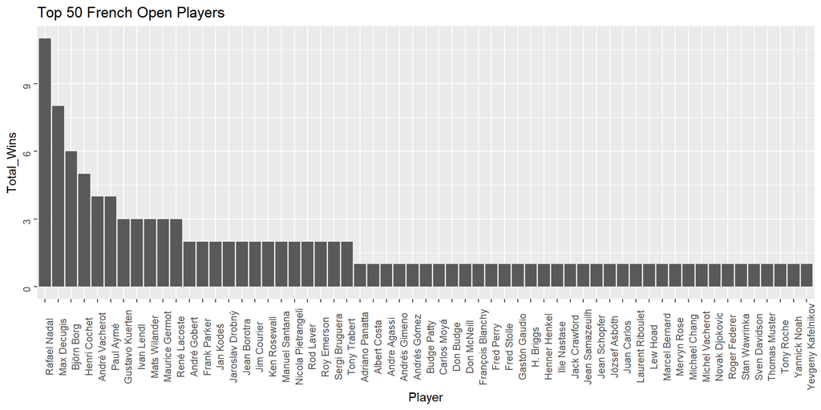

```r
tidyOrder$Player<-factor(tidyOrder$Player,levels = tidyOrder$Player[order(-tidyOrder$Total_Wins)])
ggplot(data=tidyOrder,aes(x=Player, y=Total_Wins))+geom_bar(stat = "identity")+theme(axis.text = element_text(angle=90))+ggtitle("Top 50 French Open Players")
```

### Wimbledon players with most wins

```r
tidyOrder<-tidyTable %>% filter(Tournament=="Wimbledon") %>% group_by(Player) %>% summarise(Total_Wins=n())
tidyOrder %>% arrange(desc(Total_Wins)) %>% kable() %>% kable_styling() %>% scroll_box(width = "910px", height = "400px")
```

| Player | Total_Wins |
| --- | --- |
| Roger Federer | 8 |
| Pete Sampras | 7 |
| William Renshaw | 7 |
| Laurence Doherty | 5 |
| Anthony Wilding | 4 |
| Björn Borg | 4 |
| Novak Djokovic | 4 |
| Reginald Doherty | 4 |
| Rod Laver | 4 |
| Arthur Gore | 3 |
| Bill Tilden | 3 |
| Boris Becker | 3 |
| Fred Perry | 3 |
| John McEnroe | 3 |
| John Newcombe | 3 |
| Wilfred Baddeley | 3 |
| Andy Murray | 2 |
| Don Budge | 2 |
| Henri Cochet | 2 |
| Jean Borotra | 2 |
| Jimmy Connors | 2 |
| John Hartley | 2 |
| Joshua Pim | 2 |
| Lew Hoad | 2 |
| Norman Brookes | 2 |
| Rafael Nadal | 2 |
| René Lacoste | 2 |
| Roy Emerson | 2 |
| Stefan Edberg | 2 |
| Alex Olmedo | 1 |
| Andre Agassi | 1 |
| Arthur Ashe | 1 |
| Ashley Cooper | 1 |
| Bob Falkenburg | 1 |
| Bobby Riggs | 1 |
| Budge Patty | 1 |
| Chuck McKinley | 1 |
| Ellsworth Vines | 1 |
| Ernest Renshaw | 1 |
| Frank Hadow | 1 |
| Frank Sedgman | 1 |
| Gerald Patterson | 1 |
| Goran Ivanievic | 1 |
| Harold Mahony | 1 |
| Herbert Lawford | 1 |
| Jack Crawford | 1 |
| Jack Kramer | 1 |
| Jan Kode | 1 |
| Jaroslav Drobný | 1 |
| Lleyton Hewitt | 1 |
| Manuel Santana | 1 |
| Michael Stich | 1 |
| Neale Fraser | 1 |
| Pat Cash | 1 |
| Richard Krajicek | 1 |
| Richard Savitt | 1 |
| Sidney Wood | 1 |
| Spencer Gore | 1 |
| Stan Smith | 1 |
| Ted Schroeder | 1 |
| Tony Trabert | 1 |
| Vic Seixas | 1 |
| William Johnston | 1 |
| Willoughby Hamilton | 1 |
| Yvon Petra | 1 |

```r
tidyOrder<-tidyOrder %>% top_n(50)
```

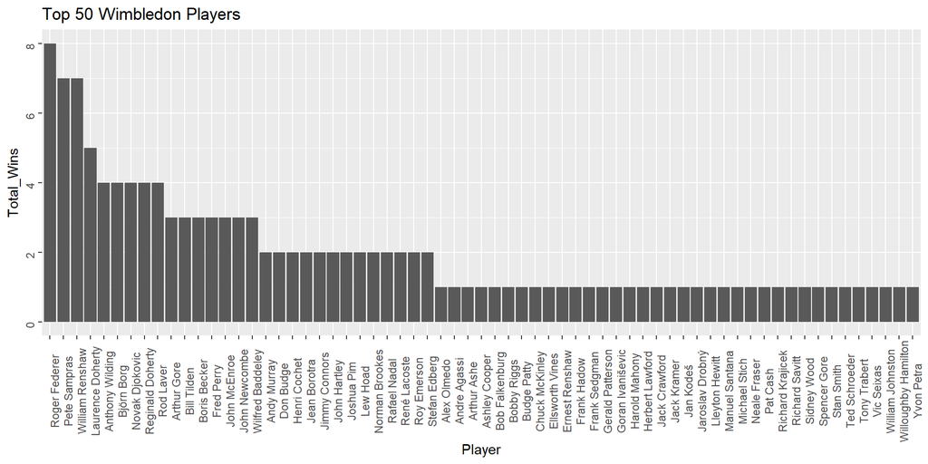

```r
tidyOrder$Player<-factor(tidyOrder$Player,levels = tidyOrder$Player[order(-tidyOrder$Total_Wins)])
ggplot(data=tidyOrder,aes(x=Player, y=Total_Wins))+geom_bar(stat = "identity")+theme(axis.text = element_text(angle=90))+ggtitle("Top 50 Wimbledon Players")
```

### US Open players with most wins

```r
tidyOrder<-tidyTable %>% filter(Tournament=="US Open") %>% group_by(Player) %>% summarise(Total_Wins=n())
tidyOrder %>% arrange(desc(Total_Wins)) %>% kable() %>% kable_styling() %>% scroll_box(width = "910px", height = "400px")
```

| Player | Total_Wins |
| --- | --- |
| Bill Tilden | 7 |
| Richard Sears | 7 |
| William Larned | 7 |
| Jimmy Connors | 5 |
| Pete Sampras | 5 |
| Roger Federer | 5 |
| John McEnroe | 4 |
| Robert Wrenn | 4 |
| Fred Perry | 3 |
| Ivan Lendl | 3 |
| Malcolm Whitman | 3 |
| Novak Djokovic | 3 |
| Oliver Campbell | 3 |
| Rafael Nadal | 3 |
| Andre Agassi | 2 |
| Don Budge | 2 |
| Ellsworth Vines | 2 |
| Frank Sedgman | 2 |
| Henry Slocum | 2 |
| Jack Kramer | 2 |
| John Newcombe | 2 |
| Ken Rosewall | 2 |
| Maurice McLoughlin | 2 |
| Neale Fraser | 2 |
| Pancho Gonzales | 2 |
| Patrick Rafter | 2 |
| René Lacoste | 2 |
| Rod Laver | 2 |
| Roy Emerson | 2 |
| Stefan Edberg | 2 |
| Tony Trabert | 2 |
| Andy Murray | 1 |
| Andy Roddick | 1 |
| Arthur Ashe | 1 |
| Arthur Larsen | 1 |
| Ashley Cooper | 1 |
| Beals Wright | 1 |
| Bobby Riggs | 1 |
| Boris Becker | 1 |
| Don McNeill | 1 |
| Fred Hovey | 1 |
| Fred Stolle | 1 |
| Henri Cochet | 1 |
| Holcombe Ward | 1 |
| Ilie Nastase | 1 |
| John Doeg | 1 |
| Juan Martín | 1 |
| Laurence Doherty | 1 |
| Lleyton Hewitt | 1 |
| Malcolm Anderson | 1 |
| Manuel Orantes | 1 |
| Manuel Santana | 1 |
| Marat Safin | 1 |
| Marin Cilic | 1 |
| Mats Wilander | 1 |
| Rafael Osuna | 1 |
| Richard Williams | 1 |
| Stan Smith | 1 |
| Stan Wawrinka | 1 |
| Vic Seixas | 1 |
| William Clothier | 1 |
| William Johnston | 1 |
| Wilmer Allison | 1 |

```r
tidyOrder<-tidyOrder %>% top_n(50)
```

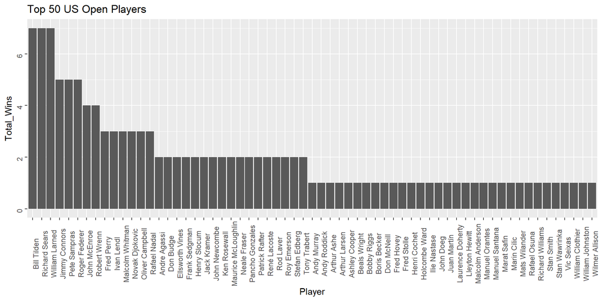

```r
tidyOrder$Player<-factor(tidyOrder$Player,levels = tidyOrder$Player[order(-tidyOrder$Total_Wins)])
ggplot(data=tidyOrder,aes(x=Player, y=Total_Wins))+geom_bar(stat = "identity")+theme(axis.text = element_text(angle=90))+ggtitle("Top 50 US Open Players")
```

### Most dominant players in the 90’s

```r
tidyOrder<-tidyTable %>% filter(Year %in% paste(seq(1990,1999,1))) %>% group_by(Player) %>% summarise(Total_Wins=n())
tidyOrder  %>% arrange(desc(Total_Wins)) %>% kable() %>% kable_styling() %>% scroll_box(width = "910px", height = "400px")
```

| Player | Total_Wins |
| --- | --- |
| Pete Sampras | 12 |
| Andre Agassi | 5 |
| Jim Courier | 4 |
| Stefan Edberg | 3 |
| Boris Becker | 2 |
| Patrick Rafter | 2 |
| Sergi Bruguera | 2 |
| Yevgeny Kafelnikov | 2 |
| Andrés Gómez | 1 |
| Carlos Moyá | 1 |
| Gustavo Kuerten | 1 |
| Ivan Lendl | 1 |
| Michael Stich | 1 |
| Petr Korda | 1 |
| Richard Krajicek | 1 |
| Thomas Muster | 1 |

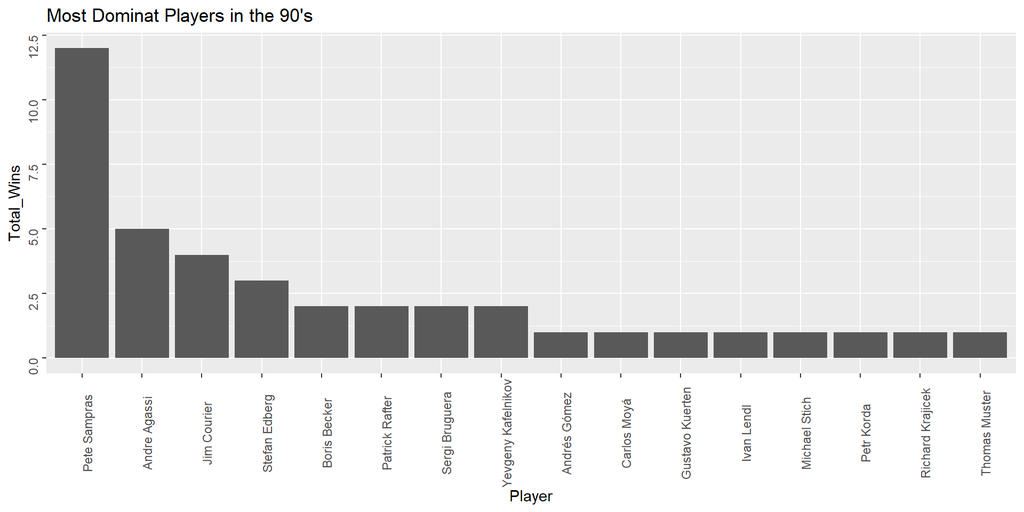

```r
tidyOrder$Player<-factor(tidyOrder$Player,levels = tidyOrder$Player[order(-tidyOrder$Total_Wins)])
ggplot(data=tidyOrder,aes(x=Player, y=Total_Wins))+geom_bar(stat = "identity")+theme(axis.text = element_text(angle=90))+ggtitle("Most Dominat Players in the 90's")
```

### Most dominant player per decade

```r
tidyCase<-tidyTable %>% mutate(Decade=paste(substr(Year,1,3),"0's",sep = "")) %>% group_by(Decade,Player) %>% summarise(Total_Wins=n()) %>% filter(Total_Wins==max(Total_Wins))
tidyCase %>% arrange(desc(Total_Wins)) %>% kable() %>% kable_styling() %>% scroll_box(width = "910px", height = "400px")
```

| Decade | Player | Total_Wins |
| --- | --- | --- |
| 2000’s | Roger Federer | 15 |
| 2010’s | Novak Djokovic | 13 |
| 1960’s | Roy Emerson | 12 |
| 1990’s | Pete Sampras | 12 |
| 1920’s | Bill Tilden | 9 |
| 1930’s | Fred Perry | 8 |
| 1880’s | Richard Sears | 7 |
| 1880’s | William Renshaw | 7 |
| 1970’s | Björn Borg | 7 |
| 1980’s | Ivan Lendl | 7 |
| 1980’s | Mats Wilander | 7 |
| 1900’s | Laurence Doherty | 6 |
| 1950’s | Tony Trabert | 5 |
| 1890’s | Robert Wrenn | 4 |
| 1910’s | Anthony Wilding | 4 |
| 1940’s | Jack Kramer | 3 |
| 1870’s | Frank Hadow | 1 |
| 1870’s | John Hartley | 1 |
| 1870’s | Spencer Gore | 1 |

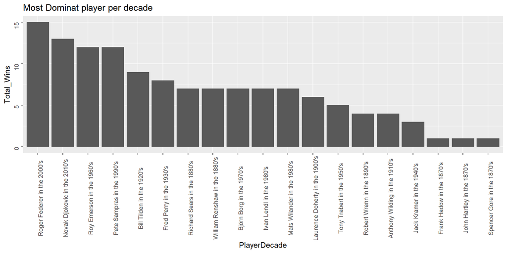

```r
tidyOrder<-tidyCase %>% mutate(PlayerDecade=paste(Player,Decade,sep = " in the "))
tidyOrder$PlayerDecade<-factor(tidyOrder$PlayerDecade,levels = tidyOrder$PlayerDecade[order(-tidyOrder$Total_Wins)])
ggplot(data=tidyOrder,aes(x=PlayerDecade, y=Total_Wins))+geom_bar(stat = "identity")+theme(axis.text = element_text(angle=90))+ggtitle("Most Dominat player per decade")
```

### Best players by surface

```r
tidyCase<-tidyTable %>% mutate(Surface=ifelse(Tournament=="Wimbledon","Grass",ifelse(Tournament=="French Open","Clay",ifelse(Tournament=="Australian Open" & strtoi(Year)<1988,"Grass",ifelse(Tournament=="Australian Open" & strtoi(Year)>1987,"Hard Court",ifelse(Tournament=="US Open" & strtoi(Year)<1975,"Grass",ifelse(Tournament=="US Open" & strtoi(Year)>1974 & strtoi(Year)<1978,"Clay",ifelse(Tournament=="US Open" & strtoi(Year)>1977,"Hard Court",NA))))))))
tidyCase %>% kable() %>% kable_styling() %>% scroll_box(width = "910px", height = "400px")
```

| Year | Tournament | Player | Surface |
| --- | --- | --- | --- |
| 1905 | Australian Open | Rodney Heath | Grass |
| 1906 | Australian Open | Anthony Wilding | Grass |
| 1907 | Australian Open | Horace Rice | Grass |
| 1908 | Australian Open | Fred Alexander | Grass |
| 1909 | Australian Open | Anthony Wilding | Grass |
| 1910 | Australian Open | Rodney Heath | Grass |
| 1911 | Australian Open | Norman Brookes | Grass |
| 1912 | Australian Open | James Cecil | Grass |
| 1913 | Australian Open | Ernie Parker | Grass |
| 1914 | Australian Open | Arthur O’Hara Wood | Grass |
| 1915 | Australian Open | Francis Lowe | Grass |
| 1920 | Australian Open | Pat O’Hara Wood | Grass |
| 1921 | Australian Open | Rhys Gemmell | Grass |
| 1922 | Australian Open | James Anderson | Grass |
| 1923 | Australian Open | Pat O’Hara Wood | Grass |
| 1924 | Australian Open | James Anderson | Grass |
| 1925 | Australian Open | James Anderson | Grass |
| 1926 | Australian Open | John Hawkes | Grass |
| 1927 | Australian Open | Gerald Patterson | Grass |
| 1928 | Australian Open | Jean Borotra | Grass |
| 1929 | Australian Open | John Gregory | Grass |
| 1930 | Australian Open | Edgar Moon | Grass |
| 1931 | Australian Open | Jack Crawford | Grass |
| 1932 | Australian Open | Jack Crawford | Grass |
| 1933 | Australian Open | Jack Crawford | Grass |
| 1934 | Australian Open | Fred Perry | Grass |
| 1935 | Australian Open | Jack Crawford | Grass |
| 1936 | Australian Open | Adrian Quist | Grass |
| 1937 | Australian Open | Vivian McGrath | Grass |
| 1938 | Australian Open | Don Budge | Grass |

[output cut: 445 more lines]

```r
tidyOrder<-tidyCase %>% group_by(Surface,Player) %>% summarise(Total_Wins=n()) #%>% filter(Total_Wins==max(Total_Wins))
tidyOrder %>% arrange(desc(Total_Wins)) %>% kable() %>% kable_styling() %>% scroll_box(width = "910px", height = "400px")
```

| Surface | Player | Total_Wins |
| --- | --- | --- |
| Clay | Rafael Nadal | 11 |
| Hard Court | Roger Federer | 11 |
| Grass | Bill Tilden | 10 |
| Grass | Roy Emerson | 10 |
| Grass | Rod Laver | 9 |
| Hard Court | Novak Djokovic | 9 |
| Clay | Max Decugis | 8 |
| Grass | Roger Federer | 8 |
| Grass | Fred Perry | 7 |
| Grass | John Newcombe | 7 |
| Grass | Pete Sampras | 7 |
| Grass | Richard Sears | 7 |
| Grass | William Larned | 7 |
| Grass | William Renshaw | 7 |
| Hard Court | Pete Sampras | 7 |
| Clay | Björn Borg | 6 |
| Grass | Anthony Wilding | 6 |
| Grass | Ken Rosewall | 6 |
| Grass | Laurence Doherty | 6 |
| Hard Court | Andre Agassi | 6 |
| Clay | Henri Cochet | 5 |
| Grass | Don Budge | 5 |
| Grass | Frank Sedgman | 5 |
| Grass | Jack Crawford | 5 |
| Hard Court | Ivan Lendl | 5 |
| Clay | André Vacherot | 4 |
| Clay | Paul Aymé | 4 |
| Grass | Ashley Cooper | 4 |
| Grass | Björn Borg | 4 |
| Grass | Jimmy Connors | 4 |

[output cut: 166 more lines]

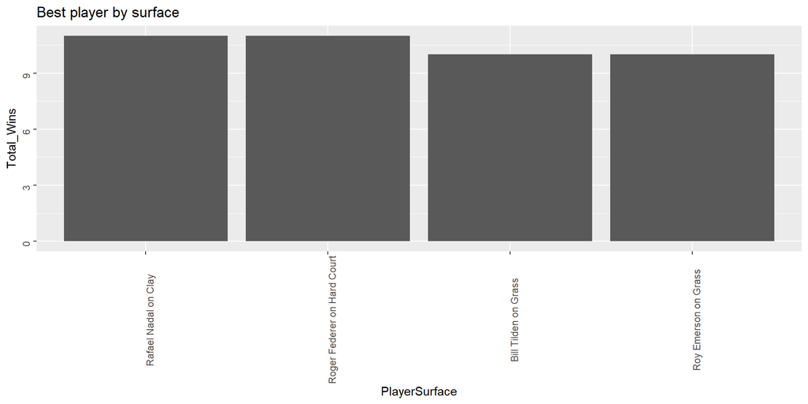

```r
tidyOrder<-tidyOrder %>% mutate(PlayerSurface=paste(Player,Surface,sep = " on "))
tidyOrder$PlayerSurface<-factor(tidyOrder$PlayerSurface,levels = tidyOrder$PlayerSurface[order(-tidyOrder$Total_Wins)])
tidyOrder %>% filter(Total_Wins==max(Total_Wins)) %>% ggplot(aes(x=PlayerSurface, y=Total_Wins))+geom_bar(stat = "identity")+theme(axis.text = element_text(angle=90))+ggtitle("Best player by surface")
```

### Adding ATP tournamets to table

```r
url<-'https://en.wikipedia.org/wiki/ATP_World_Tour_Masters_1000'
webPage<- url %>% read_html()
vectorTable<-webPage %>% html_nodes('th') %>% html_text()
tableHeaderPositions<-which("Indian Wells"==vectorTable)
tableHeaderLengths<-diff(tableHeaderPositions)
tableHeaders<-c()
j<-seq(1:(length(tableHeaderPositions)-1))
for (i in j) {
  tableHeaders[[i]]<-vectorTable[(tableHeaderPositions[i]):((tableHeaderPositions[i])+tableHeaderLengths[i]-2)]
}
i<-i+1
tableHeaders[[i]]<-vectorTable[(tableHeaderPositions[i]):((tableHeaderPositions[i])+10)]
vectorTable<-webPage %>% html_nodes('td') %>% html_text()

getMastersTable<-function(endYear,startYear) {
  years<-paste(c(endYear:startYear))
  m<-match(years,vectorTable)
  n<-diff(m)
  #we copy all the years with complete tournament data on to a new vector
  x<-c()
  i<-1
  for (nn in n) {x<-c(x,vectorTable[m[i]:(m[i]+(nn-1))]); i<-i+1}
  x<-c(x,vectorTable[m[i]:(m[i]+(nn-1))])
  tblTable<-tbl_df(as.data.frame(matrix(x,nrow=length(x)/10,ncol=10,byrow = TRUE)))
  tblTable<-setNames(tblTable,c('Year',tableHeaders[[1]]))
  tidyTableMasters<-gather(tblTable,"Tournament","Player",2:10)
  tidyTableMasters$Player<-str_extract(tidyTableMasters$Player," [:alpha:][:alpha:]+")
  tidyTableMasters<-tidyTableMasters %>% na.omit()
  return(mutate(tidyTableMasters,Tournament_Type='Masters'))
}
tidyTableMasters<-getMastersTable(2018,2011)
#we clean the original Grand Slam table to only show last names so we can use it together with the Masters table
tidyTable$Player<-str_extract(tidyTable$Player," [A-Z][:alpha:]+")
tidyTable<-mutate(tidyTable,Tournament_Type='Grand Slam')
tidyTableAll<-full_join(tidyTable,tidyTableMasters)
tidyTableAll %>% kable() %>% kable_styling() %>% scroll_box(width = "910px", height = "400px")
```

| Year | Tournament | Player | Tournament_Type |
| --- | --- | --- | --- |
| 1905 | Australian Open | Heath | Grand Slam |
| 1906 | Australian Open | Wilding | Grand Slam |
| 1907 | Australian Open | Rice | Grand Slam |
| 1908 | Australian Open | Alexander | Grand Slam |
| 1909 | Australian Open | Wilding | Grand Slam |
| 1910 | Australian Open | Heath | Grand Slam |
| 1911 | Australian Open | Brookes | Grand Slam |
| 1912 | Australian Open | Cecil | Grand Slam |
| 1913 | Australian Open | Parker | Grand Slam |
| 1914 | Australian Open | Wood | Grand Slam |
| 1915 | Australian Open | Lowe | Grand Slam |
| 1920 | Australian Open | Wood | Grand Slam |
| 1921 | Australian Open | Gemmell | Grand Slam |
| 1922 | Australian Open | Anderson | Grand Slam |
| 1923 | Australian Open | Wood | Grand Slam |
| 1924 | Australian Open | Anderson | Grand Slam |
| 1925 | Australian Open | Anderson | Grand Slam |
| 1926 | Australian Open | Hawkes | Grand Slam |
| 1927 | Australian Open | Patterson | Grand Slam |
| 1928 | Australian Open | Borotra | Grand Slam |
| 1929 | Australian Open | Gregory | Grand Slam |
| 1930 | Australian Open | Moon | Grand Slam |
| 1931 | Australian Open | Crawford | Grand Slam |
| 1932 | Australian Open | Crawford | Grand Slam |
| 1933 | Australian Open | Crawford | Grand Slam |
| 1934 | Australian Open | Perry | Grand Slam |
| 1935 | Australian Open | Crawford | Grand Slam |
| 1936 | Australian Open | Quist | Grand Slam |
| 1937 | Australian Open | McGrath | Grand Slam |
| 1938 | Australian Open | Budge | Grand Slam |

[output cut: 515 more lines]

```r
tidyTableAll<-full_join(tidyTableAll,getMastersTable(2010,2009))
tidyTableAll<-full_join(tidyTableAll,getMastersTable(2008,2004))
tidyTableAll<-full_join(tidyTableAll,getMastersTable(2003,2002))
tidyTableAll<-full_join(tidyTableAll,getMastersTable(2001,2000))
tidyTableAll<-full_join(tidyTableAll,getMastersTable(1999,1996))
tidyTableAll<-full_join(tidyTableAll,getMastersTable(1995,1990))
tidyTableAll %>% kable() %>% kable_styling() %>% scroll_box(width = "910px", height = "400px")
```

| Year | Tournament | Player | Tournament_Type |
| --- | --- | --- | --- |
| 1905 | Australian Open | Heath | Grand Slam |
| 1906 | Australian Open | Wilding | Grand Slam |
| 1907 | Australian Open | Rice | Grand Slam |
| 1908 | Australian Open | Alexander | Grand Slam |
| 1909 | Australian Open | Wilding | Grand Slam |
| 1910 | Australian Open | Heath | Grand Slam |
| 1911 | Australian Open | Brookes | Grand Slam |
| 1912 | Australian Open | Cecil | Grand Slam |
| 1913 | Australian Open | Parker | Grand Slam |
| 1914 | Australian Open | Wood | Grand Slam |
| 1915 | Australian Open | Lowe | Grand Slam |
| 1920 | Australian Open | Wood | Grand Slam |
| 1921 | Australian Open | Gemmell | Grand Slam |
| 1922 | Australian Open | Anderson | Grand Slam |
| 1923 | Australian Open | Wood | Grand Slam |
| 1924 | Australian Open | Anderson | Grand Slam |
| 1925 | Australian Open | Anderson | Grand Slam |
| 1926 | Australian Open | Hawkes | Grand Slam |
| 1927 | Australian Open | Patterson | Grand Slam |
| 1928 | Australian Open | Borotra | Grand Slam |
| 1929 | Australian Open | Gregory | Grand Slam |
| 1930 | Australian Open | Moon | Grand Slam |
| 1931 | Australian Open | Crawford | Grand Slam |
| 1932 | Australian Open | Crawford | Grand Slam |
| 1933 | Australian Open | Crawford | Grand Slam |
| 1934 | Australian Open | Perry | Grand Slam |
| 1935 | Australian Open | Crawford | Grand Slam |
| 1936 | Australian Open | Quist | Grand Slam |
| 1937 | Australian Open | McGrath | Grand Slam |
| 1938 | Australian Open | Budge | Grand Slam |

[output cut: 704 more lines]

### Players with most overall wins

```r
tidyTableAll %>% group_by(Player) %>% summarise(Total_Wins=n())  %>% arrange(desc(Total_Wins)) %>% kable() %>% kable_styling() %>% scroll_box(width = "910px", height = "400px")
```

| Player | Total_Wins |
| --- | --- |
| Nadal | 50 |
| Federer | 47 |
| Djokovic | 45 |
| Agassi | 25 |
| Sampras | 25 |
| Murray | 17 |
| Emerson | 12 |
| Becker | 11 |
| Laver | 11 |
| Borg | 10 |
| Doherty | 10 |
| Edberg | 10 |
| Tilden | 10 |
| Courier | 9 |
| Muster | 9 |
| Chang | 8 |
| Cochet | 8 |
| Connors | 8 |
| Decugis | 8 |
| Kuerten | 8 |
| Lendl | 8 |
| Perry | 8 |
| Renshaw | 8 |
| Rosewall | 8 |
| Lacoste | 7 |
| Larned | 7 |
| McEnroe | 7 |
| Newcombe | 7 |
| Safin | 7 |
| Sears | 7 |

[output cut: 157 more lines]

```r
tidyOrder<-tidyTableAll %>% group_by(Player) %>% summarise(Total_Wins=n()) %>% top_n(50)
```

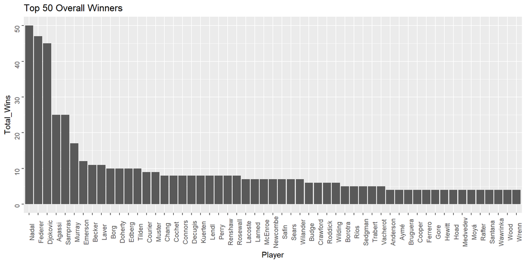

```r
tidyOrder$Player<-factor(tidyOrder$Player,levels = tidyOrder$Player[order(-tidyOrder$Total_Wins)])
ggplot(data=tidyOrder,aes(x=Player, y=Total_Wins))+geom_bar(stat = "identity")+theme(axis.text = element_text(angle=90))+ggtitle("Top 50 Overall Winners")
```

## Data set 2

### Untidy data - airline safety by Ravi Itwaru

https://raw.githubusercontent.com/fivethirtyeight/data/master/airline-safety/airline-safety.csv

Below is a dataset I found on airline safety. We can perform some analyst on this data to find out which airlines had the worst record on fatalities and incidents.

```r
#load csv data from github into a table
library(RCurl)
csvTable<-tbl_df(read.csv(text = getURL("https://raw.githubusercontent.com/fivethirtyeight/data/master/airline-safety/airline-safety.csv  ")))
csvTable %>% kable() %>% kable_styling() %>% scroll_box(width = "910px", height = "400px")
```

| airline | avail_seat_km_per_week | incidents_85_99 | fatal_accidents_85_99 | fatalities_85_99 | incidents_00_14 | fatal_accidents_00_14 | fatalities_00_14 |
| --- | --- | --- | --- | --- | --- | --- | --- |
| Aer Lingus | 320906734 | 2 | 0 | 0 | 0 | 0 | 0 |
| Aeroflot* | 1197672318 | 76 | 14 | 128 | 6 | 1 | 88 |
| Aerolineas Argentinas | 385803648 | 6 | 0 | 0 | 1 | 0 | 0 |
| Aeromexico* | 596871813 | 3 | 1 | 64 | 5 | 0 | 0 |
| Air Canada | 1865253802 | 2 | 0 | 0 | 2 | 0 | 0 |
| Air France | 3004002661 | 14 | 4 | 79 | 6 | 2 | 337 |
| Air India* | 869253552 | 2 | 1 | 329 | 4 | 1 | 158 |
| Air New Zealand* | 710174817 | 3 | 0 | 0 | 5 | 1 | 7 |
| Alaska Airlines* | 965346773 | 5 | 0 | 0 | 5 | 1 | 88 |
| Alitalia | 698012498 | 7 | 2 | 50 | 4 | 0 | 0 |
| All Nippon Airways | 1841234177 | 3 | 1 | 1 | 7 | 0 | 0 |
| American* | 5228357340 | 21 | 5 | 101 | 17 | 3 | 416 |
| Austrian Airlines | 358239823 | 1 | 0 | 0 | 1 | 0 | 0 |
| Avianca | 396922563 | 5 | 3 | 323 | 0 | 0 | 0 |
| British Airways* | 3179760952 | 4 | 0 | 0 | 6 | 0 | 0 |
| Cathay Pacific* | 2582459303 | 0 | 0 | 0 | 2 | 0 | 0 |
| China Airlines | 813216487 | 12 | 6 | 535 | 2 | 1 | 225 |
| Condor | 417982610 | 2 | 1 | 16 | 0 | 0 | 0 |
| COPA | 550491507 | 3 | 1 | 47 | 0 | 0 | 0 |
| Delta / Northwest* | 6525658894 | 24 | 12 | 407 | 24 | 2 | 51 |
| Egyptair | 557699891 | 8 | 3 | 282 | 4 | 1 | 14 |
| El Al | 335448023 | 1 | 1 | 4 | 1 | 0 | 0 |
| Ethiopian Airlines | 488560643 | 25 | 5 | 167 | 5 | 2 | 92 |
| Finnair | 506464950 | 1 | 0 | 0 | 0 | 0 | 0 |
| Garuda Indonesia | 613356665 | 10 | 3 | 260 | 4 | 2 | 22 |
| Gulf Air | 301379762 | 1 | 0 | 0 | 3 | 1 | 143 |
| Hawaiian Airlines | 493877795 | 0 | 0 | 0 | 1 | 0 | 0 |
| Iberia | 1173203126 | 4 | 1 | 148 | 5 | 0 | 0 |
| Japan Airlines | 1574217531 | 3 | 1 | 520 | 0 | 0 | 0 |
| Kenya Airways | 277414794 | 2 | 0 | 0 | 2 | 2 | 283 |
| KLM* | 1874561773 | 7 | 1 | 3 | 1 | 0 | 0 |
| Korean Air | 1734522605 | 12 | 5 | 425 | 1 | 0 | 0 |
| LAN Airlines | 1001965891 | 3 | 2 | 21 | 0 | 0 | 0 |
| Lufthansa* | 3426529504 | 6 | 1 | 2 | 3 | 0 | 0 |
| Malaysia Airlines | 1039171244 | 3 | 1 | 34 | 3 | 2 | 537 |
| Pakistan International | 348563137 | 8 | 3 | 234 | 10 | 2 | 46 |
| Philippine Airlines | 413007158 | 7 | 4 | 74 | 2 | 1 | 1 |
| Qantas* | 1917428984 | 1 | 0 | 0 | 5 | 0 | 0 |
| Royal Air Maroc | 295705339 | 5 | 3 | 51 | 3 | 0 | 0 |
| SAS* | 682971852 | 5 | 0 | 0 | 6 | 1 | 110 |
| Saudi Arabian | 859673901 | 7 | 2 | 313 | 11 | 0 | 0 |
| Singapore Airlines | 2376857805 | 2 | 2 | 6 | 2 | 1 | 83 |
| South African | 651502442 | 2 | 1 | 159 | 1 | 0 | 0 |
| Southwest Airlines | 3276525770 | 1 | 0 | 0 | 8 | 0 | 0 |
| Sri Lankan / AirLanka | 325582976 | 2 | 1 | 14 | 4 | 0 | 0 |
| SWISS* | 792601299 | 2 | 1 | 229 | 3 | 0 | 0 |
| TACA | 259373346 | 3 | 1 | 3 | 1 | 1 | 3 |
| TAM | 1509195646 | 8 | 3 | 98 | 7 | 2 | 188 |
| TAP - Air Portugal | 619130754 | 0 | 0 | 0 | 0 | 0 | 0 |
| Thai Airways | 1702802250 | 8 | 4 | 308 | 2 | 1 | 1 |
| Turkish Airlines | 1946098294 | 8 | 3 | 64 | 8 | 2 | 84 |
| United / Continental* | 7139291291 | 19 | 8 | 319 | 14 | 2 | 109 |
| US Airways / America West* | 2455687887 | 16 | 7 | 224 | 11 | 2 | 23 |
| Vietnam Airlines | 625084918 | 7 | 3 | 171 | 1 | 0 | 0 |
| Virgin Atlantic | 1005248585 | 1 | 0 | 0 | 0 | 0 | 0 |
| Xiamen Airlines | 430462962 | 9 | 1 | 82 | 2 | 0 | 0 |

```r
#we save the table to a csv file
write.csv(csvTable,file="airline-safety.csv",row.names = FALSE)
csvTable<-tbl_df(read.csv(file="airline-safety.csv", header=TRUE, sep=",",colClasses = "character"))

#with the data now in a data frame in R, we build our tidy table
#first we go from wide to tidy by creating a column for variables Type and # of Incidents
tidyTable<-csvTable %>% gather("Type","Incidents",3:8)
#second we split the incident column becouse it also contains info of the period of the observation
tidyTable<-tidyTable %>% sapply( function(x) str_replace(x,"s_","s-"),USE.NAMES = FALSE)
#we create a new period column so that each column is a separate variable
tidyTable<-tbl_df(tidyTable) %>% separate(Type,sep = "-",c('Type','Period'))
tidyTable %>% kable() %>% kable_styling() %>% scroll_box(width = "910px", height = "400px")
```

| airline | avail_seat_km_per_week | Type | Period | Incidents |
| --- | --- | --- | --- | --- |
| Aer Lingus | 320906734 | incidents | 85_99 | 2 |
| Aeroflot* | 1197672318 | incidents | 85_99 | 76 |
| Aerolineas Argentinas | 385803648 | incidents | 85_99 | 6 |
| Aeromexico* | 596871813 | incidents | 85_99 | 3 |
| Air Canada | 1865253802 | incidents | 85_99 | 2 |
| Air France | 3004002661 | incidents | 85_99 | 14 |
| Air India* | 869253552 | incidents | 85_99 | 2 |
| Air New Zealand* | 710174817 | incidents | 85_99 | 3 |
| Alaska Airlines* | 965346773 | incidents | 85_99 | 5 |
| Alitalia | 698012498 | incidents | 85_99 | 7 |
| All Nippon Airways | 1841234177 | incidents | 85_99 | 3 |
| American* | 5228357340 | incidents | 85_99 | 21 |
| Austrian Airlines | 358239823 | incidents | 85_99 | 1 |
| Avianca | 396922563 | incidents | 85_99 | 5 |
| British Airways* | 3179760952 | incidents | 85_99 | 4 |
| Cathay Pacific* | 2582459303 | incidents | 85_99 | 0 |
| China Airlines | 813216487 | incidents | 85_99 | 12 |
| Condor | 417982610 | incidents | 85_99 | 2 |
| COPA | 550491507 | incidents | 85_99 | 3 |
| Delta / Northwest* | 6525658894 | incidents | 85_99 | 24 |
| Egyptair | 557699891 | incidents | 85_99 | 8 |
| El Al | 335448023 | incidents | 85_99 | 1 |
| Ethiopian Airlines | 488560643 | incidents | 85_99 | 25 |
| Finnair | 506464950 | incidents | 85_99 | 1 |
| Garuda Indonesia | 613356665 | incidents | 85_99 | 10 |
| Gulf Air | 301379762 | incidents | 85_99 | 1 |
| Hawaiian Airlines | 493877795 | incidents | 85_99 | 0 |
| Iberia | 1173203126 | incidents | 85_99 | 4 |
| Japan Airlines | 1574217531 | incidents | 85_99 | 3 |
| Kenya Airways | 277414794 | incidents | 85_99 | 2 |

[output cut: 306 more lines]

### Airlines with most incidents

```r
tidyOrder<-tidyTable %>% group_by(airline) %>% summarise(Total_Incidents=sum(strtoi(Incidents)))  %>% arrange(desc(Total_Incidents))
tidyOrder %>% kable() %>% kable_styling() %>% scroll_box(width = "910px", height = "400px")
```

| airline | Total_Incidents |
| --- | --- |
| China Airlines | 781 |
| Malaysia Airlines | 580 |
| American* | 563 |
| Japan Airlines | 524 |
| Delta / Northwest* | 520 |
| Air India* | 495 |
| United / Continental* | 471 |
| Korean Air | 443 |
| Air France | 442 |
| Saudi Arabian | 333 |
| Avianca | 331 |
| Thai Airways | 324 |
| Aeroflot* | 313 |
| Egyptair | 312 |
| TAM | 306 |
| Pakistan International | 303 |
| Garuda Indonesia | 301 |
| Ethiopian Airlines | 296 |
| Kenya Airways | 289 |
| US Airways / America West* | 283 |
| SWISS* | 235 |
| Vietnam Airlines | 182 |
| Turkish Airlines | 169 |
| South African | 163 |
| Iberia | 158 |
| Gulf Air | 148 |
| SAS* | 122 |
| Alaska Airlines* | 99 |
| Singapore Airlines | 96 |
| Xiamen Airlines | 94 |
| Philippine Airlines | 89 |
| Aeromexico* | 73 |
| Alitalia | 63 |
| Royal Air Maroc | 62 |
| COPA | 51 |
| LAN Airlines | 26 |
| Sri Lankan / AirLanka | 21 |
| Condor | 19 |
| Air New Zealand* | 16 |
| All Nippon Airways | 12 |
| KLM* | 12 |
| Lufthansa* | 12 |
| TACA | 12 |
| British Airways* | 10 |
| Southwest Airlines | 9 |
| Aerolineas Argentinas | 7 |
| El Al | 7 |
| Qantas* | 6 |
| Air Canada | 4 |
| Aer Lingus | 2 |
| Austrian Airlines | 2 |
| Cathay Pacific* | 2 |
| Finnair | 1 |
| Hawaiian Airlines | 1 |
| Virgin Atlantic | 1 |
| TAP - Air Portugal | 0 |

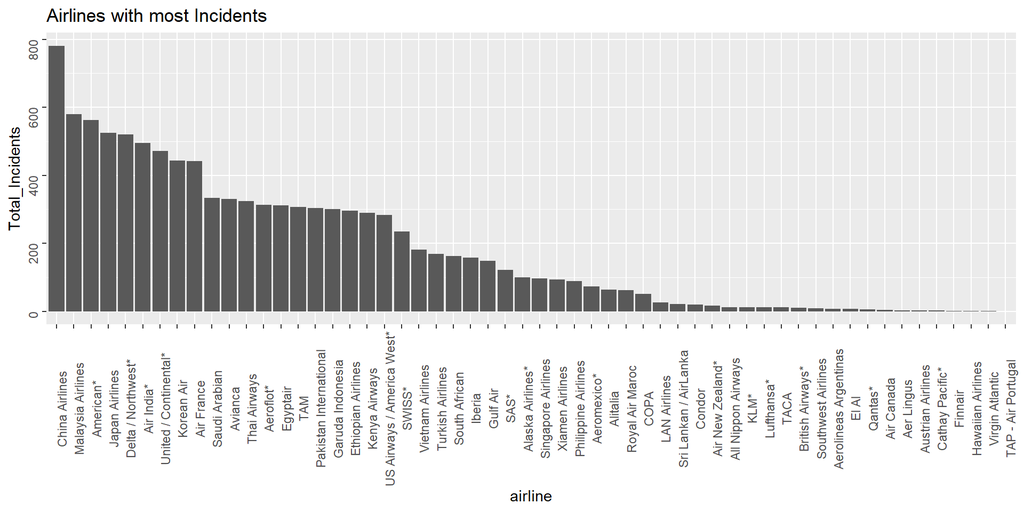

```r
tidyOrder$airline<-factor(tidyOrder$airline,levels = tidyOrder$airline[order(-tidyOrder$Total_Incidents)])
ggplot(data=tidyOrder,aes(x=airline, y=Total_Incidents))+geom_bar(stat = "identity")+theme(axis.text = element_text(angle=90))+ggtitle("Airlines with most Incidents")
```

### Airlines with most fatal incidents

```r
tidyOrder<-tidyTable %>% filter(Type=='fatal_accidents') %>% group_by(airline) %>% summarise(Total_Incidents=sum(strtoi(Incidents)))  %>% arrange(desc(Total_Incidents))
tidyOrder %>% kable() %>% kable_styling() %>% scroll_box(width = "910px", height = "400px")
```

| airline | Total_Incidents |
| --- | --- |
| Aeroflot* | 15 |
| Delta / Northwest* | 14 |
| United / Continental* | 10 |
| US Airways / America West* | 9 |
| American* | 8 |
| China Airlines | 7 |
| Ethiopian Airlines | 7 |
| Air France | 6 |
| Garuda Indonesia | 5 |
| Korean Air | 5 |
| Pakistan International | 5 |
| Philippine Airlines | 5 |
| TAM | 5 |
| Thai Airways | 5 |
| Turkish Airlines | 5 |
| Egyptair | 4 |
| Avianca | 3 |
| Malaysia Airlines | 3 |
| Royal Air Maroc | 3 |
| Singapore Airlines | 3 |
| Vietnam Airlines | 3 |
| Air India* | 2 |
| Alitalia | 2 |
| Kenya Airways | 2 |
| LAN Airlines | 2 |
| Saudi Arabian | 2 |
| TACA | 2 |
| Aeromexico* | 1 |
| Air New Zealand* | 1 |
| Alaska Airlines* | 1 |
| All Nippon Airways | 1 |
| Condor | 1 |
| COPA | 1 |
| El Al | 1 |
| Gulf Air | 1 |
| Iberia | 1 |
| Japan Airlines | 1 |
| KLM* | 1 |
| Lufthansa* | 1 |
| SAS* | 1 |
| South African | 1 |
| Sri Lankan / AirLanka | 1 |
| SWISS* | 1 |
| Xiamen Airlines | 1 |
| Aer Lingus | 0 |
| Aerolineas Argentinas | 0 |
| Air Canada | 0 |
| Austrian Airlines | 0 |
| British Airways* | 0 |
| Cathay Pacific* | 0 |
| Finnair | 0 |
| Hawaiian Airlines | 0 |
| Qantas* | 0 |
| Southwest Airlines | 0 |
| TAP - Air Portugal | 0 |
| Virgin Atlantic | 0 |

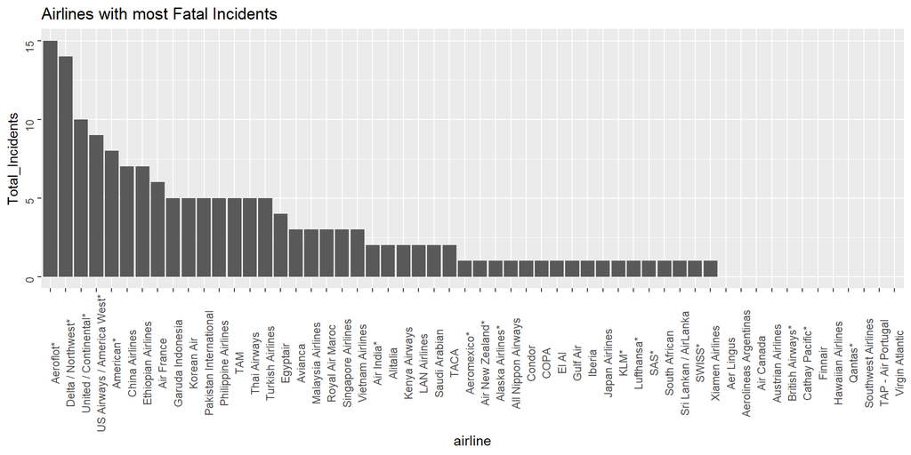

```r
tidyOrder$airline<-factor(tidyOrder$airline,levels = tidyOrder$airline[order(-tidyOrder$Total_Incidents)])
ggplot(data=tidyOrder,aes(x=airline, y=Total_Incidents))+geom_bar(stat = "identity")+theme(axis.text = element_text(angle=90))+ggtitle("Airlines with most Fatal Incidents")
```

### Airlines with most normalized incidents

```r
tidyOrder<-tidyTable %>% group_by(airline) %>% summarise(Total_IncidentsPERavail_seat_km_per_week=sum(as.numeric(Incidents))/(sum(as.numeric(avail_seat_km_per_week))/n()))  %>% arrange(desc(Total_IncidentsPERavail_seat_km_per_week))
tidyOrder %>% kable(digits = 10) %>% kable_styling() %>% scroll_box(width = "910px", height = "400px")
```

| airline | Total_IncidentsPERavail_seat_km_per_week |
| --- | --- |
| Kenya Airways | 1.0418e-06 |
| China Airlines | 9.6040e-07 |
| Pakistan International | 8.6930e-07 |
| Avianca | 8.3390e-07 |
| Ethiopian Airlines | 6.0590e-07 |
| Air India* | 5.6950e-07 |
| Egyptair | 5.5940e-07 |
| Malaysia Airlines | 5.5810e-07 |
| Gulf Air | 4.9110e-07 |
| Garuda Indonesia | 4.9070e-07 |
| Saudi Arabian | 3.8740e-07 |
| Japan Airlines | 3.3290e-07 |
| SWISS* | 2.9650e-07 |
| Vietnam Airlines | 2.9120e-07 |
| Aeroflot* | 2.6130e-07 |
| Korean Air | 2.5540e-07 |
| South African | 2.5020e-07 |
| Xiamen Airlines | 2.1840e-07 |
| Philippine Airlines | 2.1550e-07 |
| Royal Air Maroc | 2.0970e-07 |
| TAM | 2.0280e-07 |
| Thai Airways | 1.9030e-07 |
| SAS* | 1.7860e-07 |
| Air France | 1.4710e-07 |
| Iberia | 1.3470e-07 |
| Aeromexico* | 1.2230e-07 |
| US Airways / America West* | 1.1520e-07 |
| American* | 1.0770e-07 |
| Alaska Airlines* | 1.0260e-07 |
| COPA | 9.2600e-08 |
| Alitalia | 9.0300e-08 |
| Turkish Airlines | 8.6800e-08 |
| Delta / Northwest* | 7.9700e-08 |
| United / Continental* | 6.6000e-08 |
| Sri Lankan / AirLanka | 6.4500e-08 |
| TACA | 4.6300e-08 |
| Condor | 4.5500e-08 |
| Singapore Airlines | 4.0400e-08 |
| LAN Airlines | 2.5900e-08 |
| Air New Zealand* | 2.2500e-08 |
| El Al | 2.0900e-08 |
| Aerolineas Argentinas | 1.8100e-08 |
| All Nippon Airways | 6.5000e-09 |
| KLM* | 6.4000e-09 |
| Aer Lingus | 6.2000e-09 |
| Austrian Airlines | 5.6000e-09 |
| Lufthansa* | 3.5000e-09 |
| British Airways* | 3.1000e-09 |
| Qantas* | 3.1000e-09 |
| Southwest Airlines | 2.7000e-09 |
| Air Canada | 2.1000e-09 |
| Hawaiian Airlines | 2.0000e-09 |
| Finnair | 2.0000e-09 |
| Virgin Atlantic | 1.0000e-09 |
| Cathay Pacific* | 8.0000e-10 |
| TAP - Air Portugal | 0.0000e+00 |

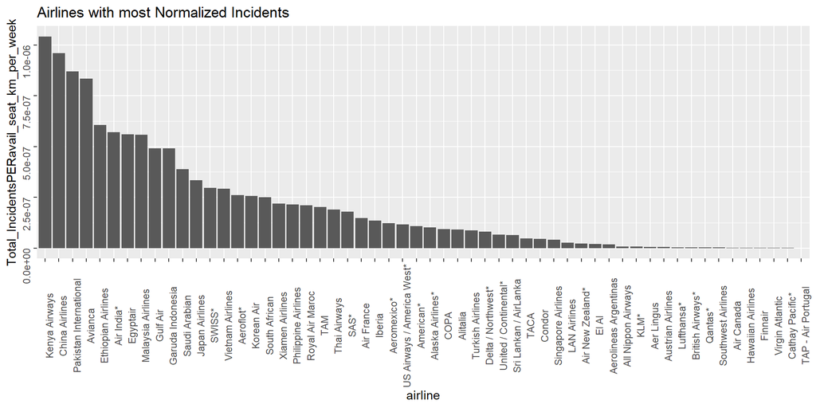

```r
tidyOrder$airline<-factor(tidyOrder$airline,levels = tidyOrder$airline[order(-tidyOrder$Total_IncidentsPERavail_seat_km_per_week)])
ggplot(data=tidyOrder,aes(x=airline, y=Total_IncidentsPERavail_seat_km_per_week))+geom_bar(stat = "identity")+theme(axis.text = element_text(angle=90))+ggtitle("Airlines with most Normalized Incidents")
```

### Airlines with most normalized fatal incidents

```r
tidyOrder<-tidyTable %>% filter(Type=='fatal_accidents') %>% group_by(airline) %>% summarise(Total_IncidentsPERavail_seat_km_per_week=sum(as.numeric(Incidents))/(sum(as.numeric(avail_seat_km_per_week))/n()))  %>% arrange(desc(Total_IncidentsPERavail_seat_km_per_week))
tidyOrder %>% kable(digits = 10) %>% kable_styling() %>% scroll_box(width = "910px", height = "400px")
```

| airline | Total_IncidentsPERavail_seat_km_per_week |
| --- | --- |
| Pakistan International | 1.43e-08 |
| Ethiopian Airlines | 1.43e-08 |
| Aeroflot* | 1.25e-08 |
| Philippine Airlines | 1.21e-08 |
| Royal Air Maroc | 1.01e-08 |
| China Airlines | 8.60e-09 |
| Garuda Indonesia | 8.20e-09 |
| TACA | 7.70e-09 |
| Avianca | 7.60e-09 |
| Kenya Airways | 7.20e-09 |
| Egyptair | 7.20e-09 |
| Vietnam Airlines | 4.80e-09 |
| US Airways / America West* | 3.70e-09 |
| Gulf Air | 3.30e-09 |
| TAM | 3.30e-09 |
| Sri Lankan / AirLanka | 3.10e-09 |
| El Al | 3.00e-09 |
| Thai Airways | 2.90e-09 |
| Malaysia Airlines | 2.90e-09 |
| Korean Air | 2.90e-09 |
| Alitalia | 2.90e-09 |
| Turkish Airlines | 2.60e-09 |
| Condor | 2.40e-09 |
| Saudi Arabian | 2.30e-09 |
| Xiamen Airlines | 2.30e-09 |
| Air India* | 2.30e-09 |
| Delta / Northwest* | 2.10e-09 |
| Air France | 2.00e-09 |
| LAN Airlines | 2.00e-09 |
| COPA | 1.80e-09 |
| Aeromexico* | 1.70e-09 |
| South African | 1.50e-09 |
| American* | 1.50e-09 |
| SAS* | 1.50e-09 |
| Air New Zealand* | 1.40e-09 |
| United / Continental* | 1.40e-09 |
| Singapore Airlines | 1.30e-09 |
| SWISS* | 1.30e-09 |
| Alaska Airlines* | 1.00e-09 |
| Iberia | 9.00e-10 |
| Japan Airlines | 6.00e-10 |
| All Nippon Airways | 5.00e-10 |
| KLM* | 5.00e-10 |
| Lufthansa* | 3.00e-10 |
| Aer Lingus | 0.00e+00 |
| Aerolineas Argentinas | 0.00e+00 |
| Air Canada | 0.00e+00 |
| Austrian Airlines | 0.00e+00 |
| British Airways* | 0.00e+00 |
| Cathay Pacific* | 0.00e+00 |
| Finnair | 0.00e+00 |
| Hawaiian Airlines | 0.00e+00 |
| Qantas* | 0.00e+00 |
| Southwest Airlines | 0.00e+00 |
| TAP - Air Portugal | 0.00e+00 |
| Virgin Atlantic | 0.00e+00 |

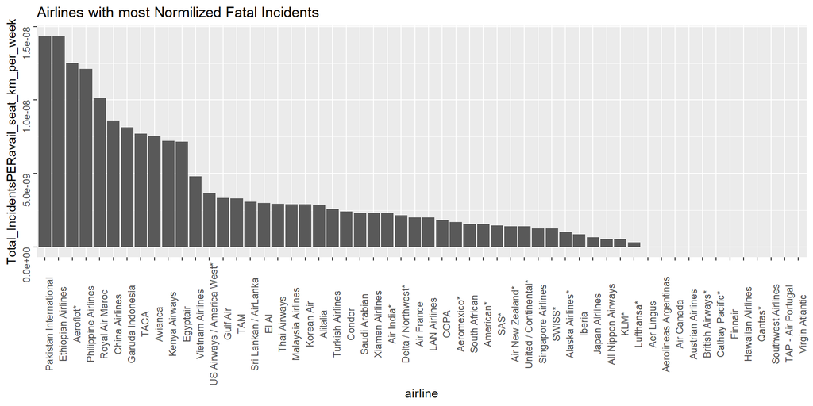

```r
tidyOrder$airline<-factor(tidyOrder$airline,levels = tidyOrder$airline[order(-tidyOrder$Total_IncidentsPERavail_seat_km_per_week)])
ggplot(data=tidyOrder,aes(x=airline, y=Total_IncidentsPERavail_seat_km_per_week))+geom_bar(stat = "identity")+theme(axis.text = element_text(angle=90))+ggtitle("Airlines with most Normilized Fatal Incidents")
```

## Data set 3

### Untidy Data by Corey Arnouts

https://en.wikipedia.org/wiki/College_football

On the college football wikipedia page there is a historical college football scoring datatable that indicates the different ways to score points in college football throughout the evolution of the game. This would be an interesting data table to extract and then see if you could find final scores of games from those time periods and compare the two tables and see what the correlation between the two is.

```r
#first we scrappe the table from the wiki site
url<-'https://en.wikipedia.org/wiki/College_football'
webPage<- url %>% read_html()
vectorTable<-webPage %>% html_nodes('tr th') %>% html_text()
tableHeader<-vectorTable[1:8]
vectorTable<-webPage %>% html_nodes('tr td') %>% html_text() %>% str_replace("present",format(Sys.Date(), "%Y"))
tableData<-vectorTable[1:(8*8)]
tblTable<-tbl_df(as.data.frame(matrix(tableData,nrow=length(tableData)/length(tableHeader),ncol=length(tableHeader),byrow = TRUE)))
tblTable<-setNames(tblTable,tableHeader)
tblTable %>% kable() %>% kable_styling() %>% scroll_box(width = "910px", height = "400px")
```

| Era | Touchdown | Field goal | Conversion (kick) | Conversion (touchdown) | Safety | Conversion safety | Defensive conversion |
| --- | --- | --- | --- | --- | --- | --- | --- |
| 1883 | 2 | 5 | 4 |  | 1 |  |  |
| 18831897 | 4 | 5 | 2 |  | 2 |  |  |
| 18981903 | 5 | 5 | 1 |  | 2 |  |  |
| 19041908 | 5 | 4 | 1 |  | 2 |  |  |
| 19091911 | 5 | 3 | 1 |  | 2 |  |  |
| 19121957 | 6 | 3 | 1 |  | 2 |  |  |
| 19581987 | 6 | 3 | 1 | 2 | 2 | 1 |  |
| 19882018 | 6 | 3 | 1 | 2 | 2 | 1 | 2 |

```r
#we save the table to a csv file
#write.csv(tblTable,file="college_football.csv",row.names = FALSE)
#we can read this csv file  --  note: knitt in windows did not handle emdash in table. emdash was replaced manually in csv file with endash. knitt had no issues on Mac
tblTable<-tbl_df(read.csv(file="college_football.csv", header=TRUE, sep=",",colClasses = "character"))
tblTable<-setNames(tblTable,tableHeader)

#we convert the wide table into a tidy table
tidyTable<-gather(tblTable,"Play","Points",2:length(tableHeader))
tidyTable %>% kable() %>% kable_styling() %>% scroll_box(width = "910px", height = "400px")
```

| Era | Play | Points |
| --- | --- | --- |
| 1883 | Touchdown | 2 |
| 1883-1897 | Touchdown | 4 |
| 1898-1903 | Touchdown | 5 |
| 1904-1908 | Touchdown | 5 |
| 1909-1911 | Touchdown | 5 |
| 1912-1957 | Touchdown | 6 |
| 1958-1987 | Touchdown | 6 |
| 1988-2018 | Touchdown | 6 |
| 1883 | Field goal | 5 |
| 1883-1897 | Field goal | 5 |
| 1898-1903 | Field goal | 5 |
| 1904-1908 | Field goal | 4 |
| 1909-1911 | Field goal | 3 |
| 1912-1957 | Field goal | 3 |
| 1958-1987 | Field goal | 3 |
| 1988-2018 | Field goal | 3 |
| 1883 | Conversion (kick) | 4 |
| 1883-1897 | Conversion (kick) | 2 |
| 1898-1903 | Conversion (kick) | 1 |
| 1904-1908 | Conversion (kick) | 1 |
| 1909-1911 | Conversion (kick) | 1 |
| 1912-1957 | Conversion (kick) | 1 |
| 1958-1987 | Conversion (kick) | 1 |
| 1988-2018 | Conversion (kick) | 1 |
| 1883 | Conversion (touchdown) |  |
| 1883-1897 | Conversion (touchdown) |  |
| 1898-1903 | Conversion (touchdown) |  |
| 1904-1908 | Conversion (touchdown) |  |
| 1909-1911 | Conversion (touchdown) |  |
| 1912-1957 | Conversion (touchdown) |  |
| 1958-1987 | Conversion (touchdown) | 2 |
| 1988-2018 | Conversion (touchdown) | 2 |
| 1883 | Safety | 1 |
| 1883-1897 | Safety | 2 |
| 1898-1903 | Safety | 2 |
| 1904-1908 | Safety | 2 |
| 1909-1911 | Safety | 2 |
| 1912-1957 | Safety | 2 |
| 1958-1987 | Safety | 2 |
| 1988-2018 | Safety | 2 |
| 1883 | Conversion safety |  |
| 1883-1897 | Conversion safety |  |
| 1898-1903 | Conversion safety |  |
| 1904-1908 | Conversion safety |  |
| 1909-1911 | Conversion safety |  |
| 1912-1957 | Conversion safety |  |
| 1958-1987 | Conversion safety | 1 |
| 1988-2018 | Conversion safety | 1 |
| 1883 | Defensive conversion |  |
| 1883-1897 | Defensive conversion |  |
| 1898-1903 | Defensive conversion |  |
| 1904-1908 | Defensive conversion |  |
| 1909-1911 | Defensive conversion |  |
| 1912-1957 | Defensive conversion |  |
| 1958-1987 | Defensive conversion |  |
| 1988-2018 | Defensive conversion | 2 |

```r
#we split the Era column into Year_start and Year_End
tidyTable<-tbl_df(tidyTable)
tidyTable<-tidyTable %>% separate(Era,sep = "-",into = c('Start_Year','End_YearTemp'))
tidyTable<-tidyTable %>% mutate(End_Year=coalesce(End_YearTemp,Start_Year)) %>% select(c(Start_Year,End_Year,Play,Points))
tidyTable<-tidyTable %>% sapply( function(x) toupper(x),USE.NAMES = FALSE)
tidyTable<-tbl_df(tidyTable)
tidyTable %>% kable() %>% kable_styling() %>% scroll_box(width = "910px", height = "400px")
```

| Start_Year | End_Year | Play | Points |
| --- | --- | --- | --- |
| 1883 | 1883 | TOUCHDOWN | 2 |
| 1883 | 1897 | TOUCHDOWN | 4 |
| 1898 | 1903 | TOUCHDOWN | 5 |
| 1904 | 1908 | TOUCHDOWN | 5 |
| 1909 | 1911 | TOUCHDOWN | 5 |
| 1912 | 1957 | TOUCHDOWN | 6 |
| 1958 | 1987 | TOUCHDOWN | 6 |
| 1988 | 2018 | TOUCHDOWN | 6 |
| 1883 | 1883 | FIELD GOAL | 5 |
| 1883 | 1897 | FIELD GOAL | 5 |
| 1898 | 1903 | FIELD GOAL | 5 |
| 1904 | 1908 | FIELD GOAL | 4 |
| 1909 | 1911 | FIELD GOAL | 3 |
| 1912 | 1957 | FIELD GOAL | 3 |
| 1958 | 1987 | FIELD GOAL | 3 |
| 1988 | 2018 | FIELD GOAL | 3 |
| 1883 | 1883 | CONVERSION (KICK) | 4 |
| 1883 | 1897 | CONVERSION (KICK) | 2 |
| 1898 | 1903 | CONVERSION (KICK) | 1 |
| 1904 | 1908 | CONVERSION (KICK) | 1 |
| 1909 | 1911 | CONVERSION (KICK) | 1 |
| 1912 | 1957 | CONVERSION (KICK) | 1 |
| 1958 | 1987 | CONVERSION (KICK) | 1 |
| 1988 | 2018 | CONVERSION (KICK) | 1 |
| 1883 | 1883 | CONVERSION (TOUCHDOWN) |  |
| 1883 | 1897 | CONVERSION (TOUCHDOWN) |  |
| 1898 | 1903 | CONVERSION (TOUCHDOWN) |  |
| 1904 | 1908 | CONVERSION (TOUCHDOWN) |  |
| 1909 | 1911 | CONVERSION (TOUCHDOWN) |  |
| 1912 | 1957 | CONVERSION (TOUCHDOWN) |  |
| 1958 | 1987 | CONVERSION (TOUCHDOWN) | 2 |
| 1988 | 2018 | CONVERSION (TOUCHDOWN) | 2 |
| 1883 | 1883 | SAFETY | 1 |
| 1883 | 1897 | SAFETY | 2 |
| 1898 | 1903 | SAFETY | 2 |
| 1904 | 1908 | SAFETY | 2 |
| 1909 | 1911 | SAFETY | 2 |
| 1912 | 1957 | SAFETY | 2 |
| 1958 | 1987 | SAFETY | 2 |
| 1988 | 2018 | SAFETY | 2 |
| 1883 | 1883 | CONVERSION SAFETY |  |
| 1883 | 1897 | CONVERSION SAFETY |  |
| 1898 | 1903 | CONVERSION SAFETY |  |
| 1904 | 1908 | CONVERSION SAFETY |  |
| 1909 | 1911 | CONVERSION SAFETY |  |
| 1912 | 1957 | CONVERSION SAFETY |  |
| 1958 | 1987 | CONVERSION SAFETY | 1 |
| 1988 | 2018 | CONVERSION SAFETY | 1 |
| 1883 | 1883 | DEFENSIVE CONVERSION |  |
| 1883 | 1897 | DEFENSIVE CONVERSION |  |
| 1898 | 1903 | DEFENSIVE CONVERSION |  |
| 1904 | 1908 | DEFENSIVE CONVERSION |  |
| 1909 | 1911 | DEFENSIVE CONVERSION |  |
| 1912 | 1957 | DEFENSIVE CONVERSION |  |
| 1958 | 1987 | DEFENSIVE CONVERSION |  |
| 1988 | 2018 | DEFENSIVE CONVERSION | 2 |

Now that we have a tidy table we can start comparing games as if they were played in different eras.

### 2018 Super Bowl: Eagles vs Patriots

We will use this table to determine if the 2018 Super Bowl would have been won if it was played using the scoring system in effect in 1883

```r
#We screpe the plays of this game from the ESPN website
url<-'http://www.sportingnews.com/us/nfl/news/philadelphia-eagles-new-england-patriots-score-updates-results-highlights-super-bowl-52/1obg36rfzvjkw170ws1sxy2tcl'
webPage<- url %>% read_html()
vectorPlays<-webPage %>% html_nodes('strong') %>% html_text()
vectorPlays<-vectorPlays[3:length(vectorPlays)]
#kick conversions after touchdown are added manually since they are not recorded on the web site
vectorPlays<-c(vectorPlays,"CONVERSION (KICK), Eagles","CONVERSION (KICK), Eagles","CONVERSION (KICK), Patriots","CONVERSION (KICK), Patriots","CONVERSION (KICK), Patriots")
vectorPlays
```

```
##  [1] "10:17 p.m."                       "10:10 p.m.  FIELD GOAL, Eagles"
##  [3] " 41-33, Eagles "                  "10:03 p.m.  TURNOVER"
##  [5] "9:56 p.m.  TOUCHDOWN, Eagles"    " 38-33, Eagles "
##  [7] "9:35 p.m.  TOUCHDOWN, Patriots"  " 33-32, Patriots "
##  [9] "9:25 p.m.  FIELD GOAL, Eagles"   " 32-26, Eagles "
## [11] "9:21 p.m. "                       "9:10 p.m.  TOUCHDOWN, Patriots"
## [13] " 29-26, Eagles "                  "8:59 p.m.  TOUCHDOWN, Eagles"
## [15] " 29-19, Eagles "                  "8:46 p.m.  TOUCHDOWN, Patriots"
## [17] " 22-19, Eagles "                  "8:41 p.m. "
## [19] "8:10 p.m. "                       "8:03 p.m.  TOUCHDOWN, Eagles"
## [21] " 22-12, Eagles "                  "7:51 p.m.  TOUCHDOWN, Patriots"
## [23] " 15-12, Eagles "                  "7:44 p.m.  TURNOVER"
## [25] "7:38 p.m.  FIELD GOAL, Patriots" " 15-6, Eagles "
## [27] "7:31 p.m.  TOUCHDOWN, Eagles"    " 15-3, Eagles "
## [29] "7:25 p.m."                        "7:21 p.m."
## [31] "7:12 p.m."                        "7:08 p.m."
## [33] "6:58 p.m.  TOUCHDOWN, Eagles:"   " 9-3, Eagles "
## [35] "6:55 p.m.  FIELD GOAL, Patriots" " 3-3, tie "
## [37] "6:41 p.m.  FIELD GOAL, Eagles"   " 3-0, Eagles "
## [39] "6:31 p.m."                        "6:27 p.m."
## [41] "6:22 p.m."                        "6:11 p.m."
## [43] "6:10 p.m."                        "5:40 p.m."
## [45] "5:37 p.m."                        "5:33 p.m."
## [47] "5:13 p.m."                        "5 p.m."
## [49] "4:54 p.m."                        "4:43 p.m."
## [51] "4:32 p.m."                        "4:13 p.m."
## [53] "4:02 p.m."                        "3:52 p.m."
## [55] "2:30 p.m."                        "CONVERSION (KICK), Eagles"
## [57] "CONVERSION (KICK), Eagles"        "CONVERSION (KICK), Patriots"
## [59] "CONVERSION (KICK), Patriots"      "CONVERSION (KICK), Patriots"
```

```r
getTeamPlayPoints<-function(GameYear,TeamName) {
  GameYear
  vectorTeamPlays<-str_extract(vectorPlays,paste(" [A-Z]+, ",TeamName,"| [A-Z]+ [A-Z]+, ",TeamName,"|[A-Z]+ \\([^()]+\\), ",TeamName,sep = "")) %>% str_extract("[A-Z]+ \\([^()]+\\)|[A-Z]+ [A-Z]+|[A-Z]+")
  vectorTeamPlays<-vectorTeamPlays[!is.na(vectorTeamPlays)]
  tablePlays<-tbl_df(data.frame(matrix(vectorTeamPlays,nrow=length(vectorTeamPlays),ncol=1,byrow=TRUE)))
  tablePlays<-setNames(tablePlays,"Play")
  #We select only 2018 rows from tidyTable and then do a join with the eagle plays table
  tidyTableFiltered<-tidyTable %>% filter(End_Year==GameYear)
  return(inner_join(tablePlays,tidyTableFiltered))
}

tableEaglePlaysPoints<-getTeamPlayPoints("2018","Eagles")
tableEaglePlaysPoints %>% kable() %>% kable_styling() %>% scroll_box(width = "910px", height = "400px")
```

| Play | Start_Year | End_Year | Points |
| --- | --- | --- | --- |
| FIELD GOAL | 1988 | 2018 | 3 |
| TOUCHDOWN | 1988 | 2018 | 6 |
| FIELD GOAL | 1988 | 2018 | 3 |
| TOUCHDOWN | 1988 | 2018 | 6 |
| TOUCHDOWN | 1988 | 2018 | 6 |
| TOUCHDOWN | 1988 | 2018 | 6 |
| TOUCHDOWN | 1988 | 2018 | 6 |
| FIELD GOAL | 1988 | 2018 | 3 |
| CONVERSION (KICK) | 1988 | 2018 | 1 |
| CONVERSION (KICK) | 1988 | 2018 | 1 |

```r
totalEaglePoints2018<-sum(strtoi(tableEaglePlaysPoints$Points))
print(paste("Eagles Score with 2018 scoring: ",toString(totalEaglePoints2018)))
```

```
## [1] "Eagles Score with 2018 scoring:  41"
```

```r
game<-c("Super Bowl")
year<-c("2018")
team<-c("Eagles")
scoring_sys<-c("2018")
score<-c(totalEaglePoints2018)

tablePatriotsPlaysPoints<-getTeamPlayPoints("2018","Patriots")
tablePatriotsPlaysPoints %>% kable() %>% kable_styling() %>% scroll_box(width = "910px", height = "400px")
```

| Play | Start_Year | End_Year | Points |
| --- | --- | --- | --- |
| TOUCHDOWN | 1988 | 2018 | 6 |
| TOUCHDOWN | 1988 | 2018 | 6 |
| TOUCHDOWN | 1988 | 2018 | 6 |
| TOUCHDOWN | 1988 | 2018 | 6 |
| FIELD GOAL | 1988 | 2018 | 3 |
| FIELD GOAL | 1988 | 2018 | 3 |
| CONVERSION (KICK) | 1988 | 2018 | 1 |
| CONVERSION (KICK) | 1988 | 2018 | 1 |
| CONVERSION (KICK) | 1988 | 2018 | 1 |

```r
totalPatriotsPoints2018<-sum(strtoi(tablePatriotsPlaysPoints$Points))
print(paste("Patriots Score with 2018 scoring: ",toString(totalPatriotsPoints2018)))
```

```
## [1] "Patriots Score with 2018 scoring:  33"
```

```r
game<-c(game,"Super Bowl")
year<-c(year,"2018")
team<-c(team,"Patriots")
scoring_sys<-c(scoring_sys,"2018")
score<-c(score,totalPatriotsPoints2018)

tableEaglePlaysPoints<-getTeamPlayPoints("1883","Eagles")
tableEaglePlaysPoints %>% kable() %>% kable_styling() %>% scroll_box(width = "910px", height = "400px")
```

| Play | Start_Year | End_Year | Points |
| --- | --- | --- | --- |
| FIELD GOAL | 1883 | 1883 | 5 |
| TOUCHDOWN | 1883 | 1883 | 2 |
| FIELD GOAL | 1883 | 1883 | 5 |
| TOUCHDOWN | 1883 | 1883 | 2 |
| TOUCHDOWN | 1883 | 1883 | 2 |
| TOUCHDOWN | 1883 | 1883 | 2 |
| TOUCHDOWN | 1883 | 1883 | 2 |
| FIELD GOAL | 1883 | 1883 | 5 |
| CONVERSION (KICK) | 1883 | 1883 | 4 |
| CONVERSION (KICK) | 1883 | 1883 | 4 |

```r
totalEaglePoints1883<-sum(strtoi(tableEaglePlaysPoints$Points))
print(paste("Eagles Score with 1883 scoring: ",toString(totalEaglePoints1883)))
```

```
## [1] "Eagles Score with 1883 scoring:  33"
```

```r
game<-c(game,"Super Bowl")
year<-c(year,"2018")
team<-c(team,"Eagles")
scoring_sys<-c(scoring_sys,"1883")
score<-c(score,totalEaglePoints1883)

tablePatriotsPlaysPoints<-getTeamPlayPoints("1883","Patriots")
tablePatriotsPlaysPoints %>% kable() %>% kable_styling() %>% scroll_box(width = "910px", height = "400px")
```

| Play | Start_Year | End_Year | Points |
| --- | --- | --- | --- |
| TOUCHDOWN | 1883 | 1883 | 2 |
| TOUCHDOWN | 1883 | 1883 | 2 |
| TOUCHDOWN | 1883 | 1883 | 2 |
| TOUCHDOWN | 1883 | 1883 | 2 |
| FIELD GOAL | 1883 | 1883 | 5 |
| FIELD GOAL | 1883 | 1883 | 5 |
| CONVERSION (KICK) | 1883 | 1883 | 4 |
| CONVERSION (KICK) | 1883 | 1883 | 4 |
| CONVERSION (KICK) | 1883 | 1883 | 4 |

```r
totalPatriotsPoints1883<-sum(strtoi(tablePatriotsPlaysPoints$Points))
print(paste("Patriots Score with 1883 scoring: ",toString(totalPatriotsPoints1883)))
```

```
## [1] "Patriots Score with 1883 scoring:  30"
```

```r
game<-c(game,"Super Bowl")
year<-c(year,"2018")
team<-c(team,"Patriots")
scoring_sys<-c(scoring_sys,"1883")
score<-c(score,totalPatriotsPoints1883)

results<-data.frame(game,year,team,scoring_sys,score)
results<-tbl_df(results)
results %>% kable() %>% kable_styling() %>% scroll_box(width = "910px")
```

| game | year | team | scoring_sys | score |
| --- | --- | --- | --- | --- |
| Super Bowl | 2018 | Eagles | 2018 | 41 |
| Super Bowl | 2018 | Patriots | 2018 | 33 |
| Super Bowl | 2018 | Eagles | 1883 | 33 |
| Super Bowl | 2018 | Patriots | 1883 | 30 |

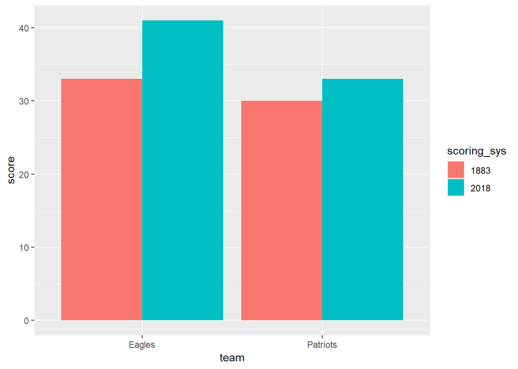

```r
results %>% group_by(scoring_sys) %>% ggplot(aes(x=team,y=score,fill=scoring_sys))+geom_bar(stat = "identity",position = 'dodge')
```

```r
print("2018 vs 1883 resluts")
```

```
## [1] "2018 vs 1883 resluts"
```

```r
print(paste("2018: Eagles ",toString(totalEaglePoints2018),"vs Patriots ",toString(totalPatriotsPoints2018)))
```

```
## [1] "2018: Eagles  41 vs Patriots  33"
```

```r
print(paste("1883: Eagles ",toString(totalEaglePoints1883),"vs Patriots ",toString(totalPatriotsPoints1883)))
```

```
## [1] "1883: Eagles  33 vs Patriots  30"
```

Eagles would have still defeted the Patriots if 1883 football scoring rules were still in effect, although by a smaller margin.